# DATA 603 Report Group 25 - Appendix

## **Equal Variance Assumption Testing**

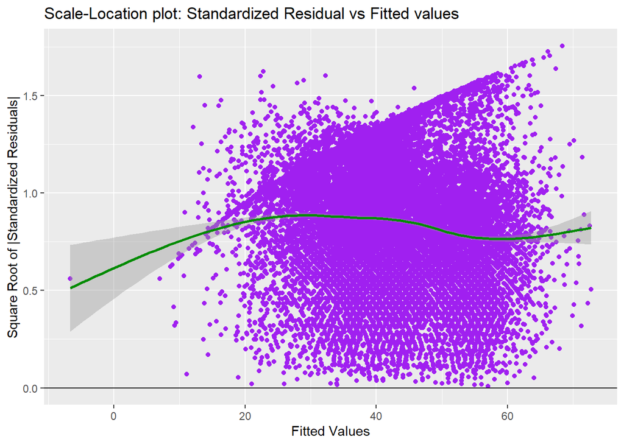

In this plot, the residuals should ideally be randomly scattered with a flat smooth line, indicating consistent variance across the range of fitted values. However, the plot shows a slight increase in the spread of residuals as fitted values grow, suggesting potential heteroscedasticity, where the variance of residuals is not constant. This violation of the equal variance assumption can affect the reliability of confidence intervals and predictions generated by the regression model. Additionally, the smooth line is not perfectly flat and shows subtle variations, reinforcing concerns about non-constant variance. There is also some clustering of residuals, particularly at lower fitted values, which warrants further investigation. To address these issues, transformations of the response variable, such as a logarithmic, could be considered. Formal tests, such as the Breusch-Pagan test, may also be conducted to confirm the presence of heteroscedasticity.

**Heteroscedasticity: The Breusch-Pagan Test**

```
##
##  studentized Breusch-Pagan test
##
## data:  Final_interaction_model
## BP = 524.08, df = 103, p-value < 2.2e-16
```

Null Hypothesis:  
$H_0:$ Heteroscedasticity is not present (homoscedasticity)  
Alternative Hypothesis:  
$H_a:$ Heteroscedasticity is present

With a p-value of 2.2e-16 being less than our $\alpha$ value of 0.05, we can reject the null hypothesis in favour of the alternative hypothesis and conclude that we do have heteroscedasticity.

## **Normality Assumption Testing**

Null Hypothesis:  
$H_0:$ The sample data are significantly normally distributed  
Alternative Hypothesis:  
$H_a:$ The sample data are not significantly normally distributed

**Q-Q plot for Normality Testing**

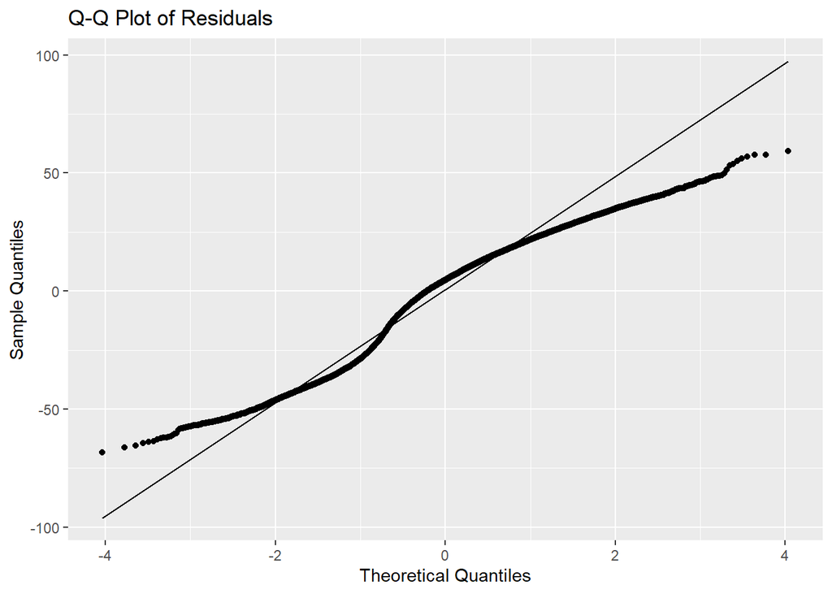